# Ejercicio 3

Los datos del archivo banana16 corresponden a 40 poblaciones de banana (Musa spp.) de las cuales 20 son clones de origen genético desconocido (recolectados en campos de productores) y 20 son variedades de uso internacional Jaffa, Gal, Gran Enanao y Williams, respectivamente (testigos).

Los datos son un extracto de la base original perteneciente al Centro Regional Chaco – Formosa de INTA.

Las variables consideradas son:

- AltPlan: altura de planta (m)
- DiamPlan: diámetro de planta (cm)
- HojasFlor: cantidad de hojas a floración
- NManos: cantidad de manos
- Rend: rendimiento (kg)

**a)** Analice las correlaciones entre variables en ambos grupos.

Matriz de correlacion

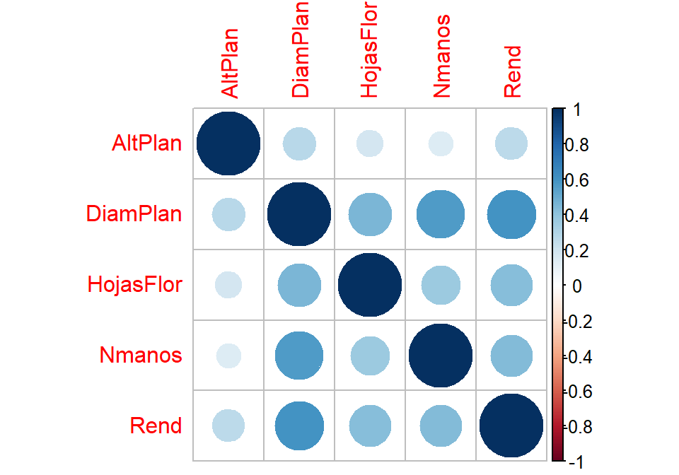

Matriz de correlacion grupo *Clones*

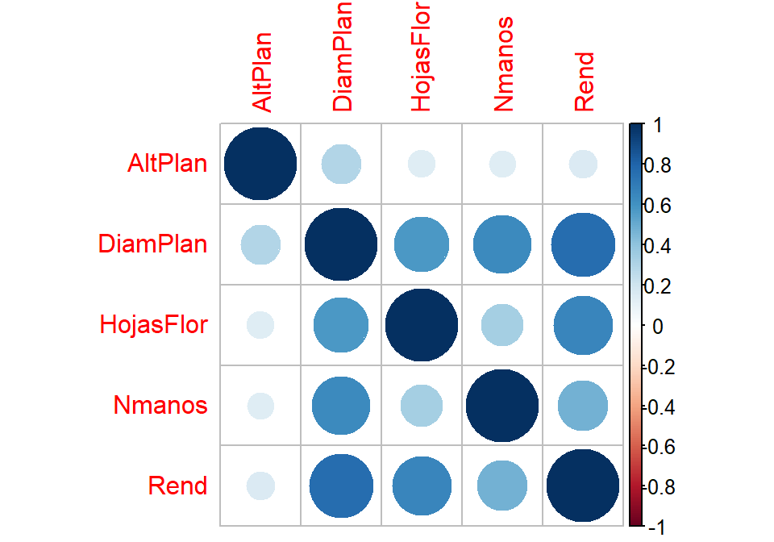

Matriz de correlacion grupo *Testigos*

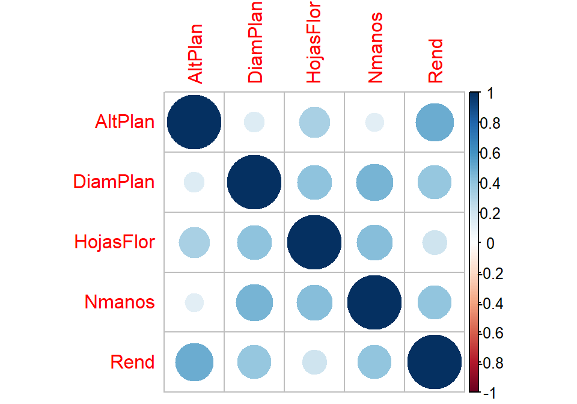

[output not shown]

Realice un Análisis Factorial Múltiple Dual y responda las siguientes cuestiones:

**b)** ¿Cuál es el porcentaje de explicación del plano principal?

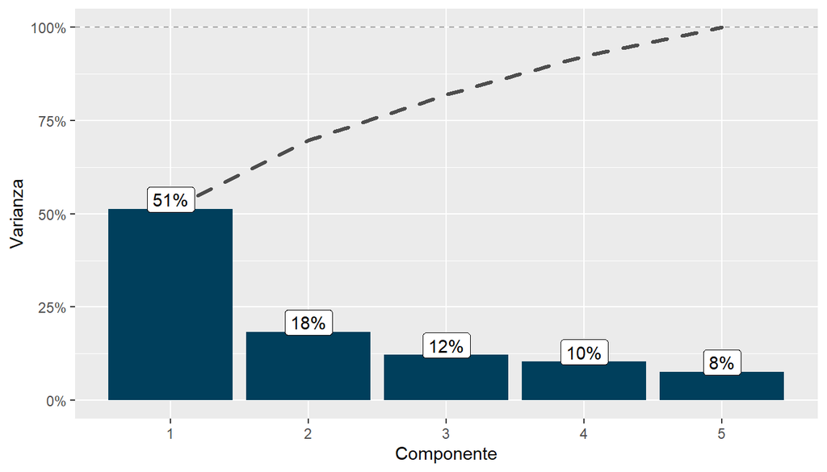

```
El porcentaje de variabilidad explicada sobre el plano princial es del 69.72%. Como puede observarse en la figura anterior, el primer autovalor explica un 51.35% mientras que el segundo un 18.37%
```

**c)** ¿Qué puede decir a partir del gráfico de las condiciones?

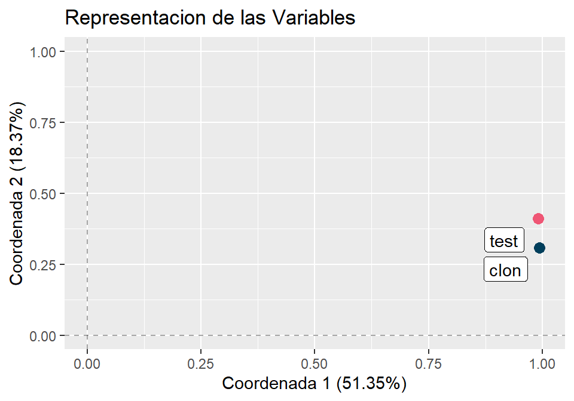

Caracterizacion de los grupos en el plano principal AFM.

[output not shown]

**d)** ¿Cómo se ven representadas en los gráficos del DMFA las conclusiones del inciso a)?

[output not shown]

Variables consesos:

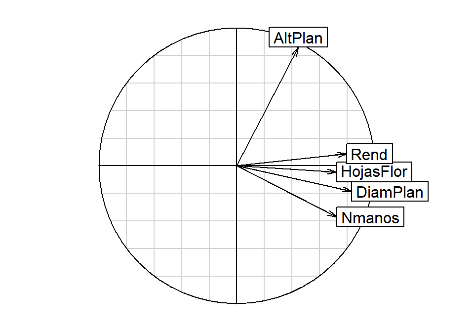

[output not shown]